# Analysis of Pytesseract for OCR number detection

## Objectives

Computer vision has the potential to completely revolutionize the society that we live in. From self-driving cars to cancer diagnosis, the range of possibilities are endless. In this report, I will analyze the effectiveness of Pytesseract, a Python OCR library, to accurately read 2-digit numbers from images. Image processing was done using OpenCV.

```python
# use the "pip install -r requirements.txt" to install the dependencies
import cv2
import numpy as np
import os
import PIL
import pytesseract
from PIL import Image
import matplotlib.pyplot as plt
import matplotlib.image as mpimg
```

## The dataset

The dataset consists of 345 images of people holding a piece of paper containing a 2-digit number. To preserve anonymity, I cropped out the faces of the invididuals in the pictures using a separate Python script.

```python
# loop through the images in the images folder and count
dir_images = "images/"
count=0
for i in os.listdir(dir_images):
    if i.lower().endswith('.jpg'):
        count+=1
print('number of images in dataset: ',count)
```

```
number of images in dataset:  345
```

## Image processing

Applying OCR using Pytesseract on the entire image would lead to highly inaccurate results. Thus, it was important to first extract the pieces of paper which the individuals were holding that contain the numbers, and apply OCR on those cropped bounding boxes instead.

### Box extraction

Successful box extraction was instrumental in increasing the accuracy of the OCR model. It was also the hardest part of building this model because it required a lot of hyper-parameter tuning. Images in the dataset had many different dimensions. Some of the images also had very high resolutions and could not be entirely visualised on the computer screen. As shown below, in the cases where the picture included someone holding the black sheet behind the piece of paper, finding the bounding box was easier.

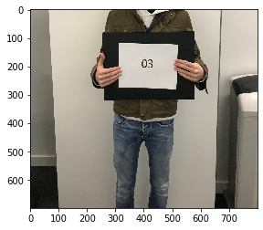

```python
filename_easy = 'images/noface_003_IMG_0687.jpg'
image_easy = mpimg.imread(filename_easy)
plt.imshow(image_easy)
plt.show()
```

However, in other cases, the bounding box was harder to detect because the picture was taken at an angle as there was no black sheet behind the white piece of paper. Adding to the difficulty, the individual shown below was also wearing a white shirt.

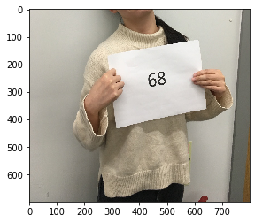

```python
# filename_hard = 'images/noface_169_IMG_0331.JPG'
filename_hard = 'images/noface_168_IMG_0344.JPG'
image_hard = mpimg.imread(filename_hard)
plt.imshow(image_hard)
plt.show()
```

The following are the high-level steps taken to find the bounding boxes:

1. Reshape the image
2. Convert the images to grayscale
3. Apply a binary conversion of the image based on a specific threshold
4. Apply a series of image processing techniques, such as dilation and erosion
5. Find contours on the resulting image
6. Filtering the rectangles to select the one that surrounds the paper

#### Reshape the image

Given the images in the dataset had various dimensions and resolutions, the first step consisted of transforming the pictures to a common size. Different picture shapes were tried out and dimensions of 800 by 700 yielded good results.

```python
image_width = 800
image_height = 700
img = cv2.imread(filename_easy)
img = cv2.resize(img, (image_width, image_height))
```

#### Convert to grayscale

In order to apply thresholding to the image, the picture must be converted from RGB color to grayscale.

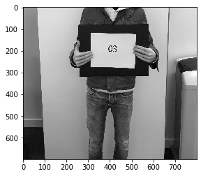

```python
imgray = cv2.cvtColor(img,cv2.COLOR_BGR2GRAY)
plt.imshow(imgray,cmap=plt.get_cmap('gray'))
plt.show()
```

#### Thresholding

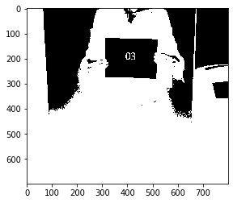

```python
thresh_value = 180
_,thresh = cv2.threshold(imgray, thresh_value,255, cv2.THRESH_BINARY_INV) #threshhold
plt.imshow(thresh,cmap=plt.get_cmap('gray'))
plt.show()
```

#### Additional pre-processing techniques: erosion and dilation

Although we can clearly see the bounding rectangle in the image above, there are additional image processing steps that can be taken to further increase the likelihood of finding the bounding rectangle, e.g. dilation and erosion.

Dilation is the process of adding pixels to the boundaries of images, whereas erosion is the reverse operation: removing pixels from the image boundaries. Given the threshold image above, dilation would expand and thicken the 'O3' digit in the image while erosion would make the number even thinner. I choose to apply dilation in order to mesh the number on the piece of paper to the point of creating a new mini-rectangle. The reason for this is that, in case there is an image where the paper rectangle is not found, I can fine-tune my parameters and select the smaller rectangle containing the digits instead. In order to do so, I have to apply a structural element to the image. Given the pieces of paper with the numbers on them have a rectangular shape, I will use the rectangular kernel as the structural element, which can be implemented using OpenCV.

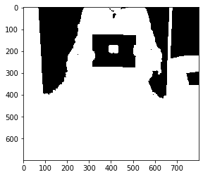

```python
kernel = cv2.getStructuringElement(cv2.MORPH_RECT,(5,5)) # rectangle kernel for structural element
dilated = cv2.dilate(thresh, kernel,iterations=2) # dilate the threshold image twice
plt.imshow(dilated,cmap=plt.get_cmap('gray'))
plt.show()
```

#### Drawing contours

My goal now is to draw the rectangle surrounding the paper containing the 2-digit number. However, if I look for contours I might found other rectangular contours other than the piece of paper. In order to limit the rectangles that I find, I can filter the rectangles by area in such a way that the rectangle with the highest area will be the piece of paper. I tuned the parameters below after analyzing multiple images.

```python
 # all find contours
contours,_ = cv2.findContours(dilated.copy(),cv2.RETR_LIST,cv2.CHAIN_APPROX_NONE)
# empty list where to store contours
box_lst=[]

# loop through contours and append to list if area restriction is met
for cnt in contours:
    area = cv2.contourArea(cnt)
    rect=cv2.minAreaRect(cnt)
    if (area>=5200) and (area<=200000) and (rect[1][0] < (2.5*rect[1][1])):
        box=cv2.boxPoints(rect)
        box=np.int0(box)

        if (box[1][0]<=5) or (box[2][1]<78) or \
            (box[3][1]<101) or (box[3][1]>695) or \
            (box[3][0]>755) or (box[1][1]<91) or (box[0][1]>677):
            pass
        else:
            box_lst.append(box)
```

Let's now visualize the bounding rectangles that we found.

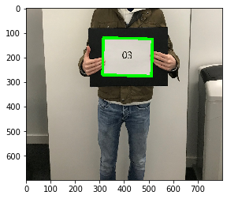

```python
box_lst = sorted(box_lst, key=cv2.contourArea, reverse=True)
cv2.drawContours(image_easy,box_lst,0,(0,255,0),10)
plt.imshow(image_easy)
plt.show()
```

For the image above, given the contour area restrictions we implemented, we find one rectangular box and it is the correct one since it wraps around the 2-digit number. Let's see if we get a similar result on the other image. Here is the threshold image.

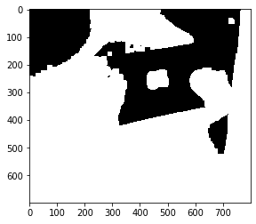

```python
img = cv2.imread(filename_hard)
img = cv2.resize(img, (image_width, image_height))
imgray = cv2.cvtColor(img,cv2.COLOR_BGR2GRAY)
thresh_value = 180
_,thresh = cv2.threshold(imgray, thresh_value,255, cv2.THRESH_BINARY_INV) #threshhold
kernel = cv2.getStructuringElement(cv2.MORPH_RECT,(5,5)) # rectangle kernel for structural element
dilated = cv2.dilate(thresh, kernel,iterations=4) # dilate the threshold image twice
plt.imshow(dilated,cmap=plt.get_cmap('gray'))
plt.show()
```

And here are the drawn contours.

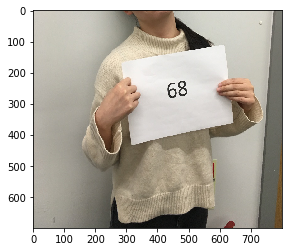

```python
 # all find contours
contours,_ = cv2.findContours(dilated.copy(),cv2.RETR_LIST,cv2.CHAIN_APPROX_NONE)
# empty list where to store contours
box_lst=[]

# loop through contours and append to list if area restriction is met
for cnt in contours:
    area = cv2.contourArea(cnt)
    rect=cv2.minAreaRect(cnt)
    if (area>=5200) and (area<=200000) and (rect[1][0] < (2.5*rect[1][1])):
        box=cv2.boxPoints(rect)
        box=np.int0(box)

        if (box[1][0]<=5) or (box[2][1]<78) or \
            (box[3][1]<101) or (box[3][1]>695) or \
            (box[3][0]>755) or (box[1][1]<91) or (box[0][1]>677):
            pass
        else:
            box_lst.append(box)
box_lst = sorted(box_lst, key=cv2.contourArea, reverse=True)
cv2.drawContours(image_easy,box_lst,0,(0,255,0),10)
plt.imshow(image_hard)
plt.show()
```

No contours were found! As a result, we code a series of if-else statements to set different parameters for different sets of images.

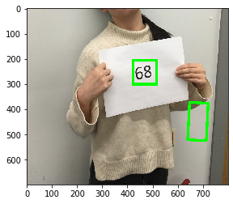

```python
hsv = cv2.cvtColor(img, cv2.COLOR_BGR2HSV)

hsv[:, :][1] = hsv[:, :][2]*1.1
hsv[:, :][2] = hsv[:, :][2]*1.1

bgr = cv2.cvtColor(img, cv2.COLOR_HSV2BGR)
gray = cv2.cvtColor(hsv, cv2.COLOR_BGR2GRAY)
edges = cv2.Canny(gray,100,200)
kernel = cv2.getStructuringElement(cv2.MORPH_RECT,(4,5))
dilated = cv2.dilate(edges, kernel,iterations=10)
contours,_ = cv2.findContours(dilated,cv2.RETR_LIST,cv2.CHAIN_APPROX_NONE)

for cnt in contours:
    area = cv2.contourArea(cnt)
    rect=cv2.minAreaRect(cnt)
    if (area>=5000) and (area<=25000):

        box=cv2.boxPoints(rect)
        box=np.int0(box)
        if (box[0][1]>695) or (box[1][1]<160) or (box[0][0]<20) or (box[2][1]<20) or (box[3][0]>780):
            pass
        else:
            box_lst.append(box)
box_lst = sorted(box_lst, key=cv2.contourArea, reverse=True)
cv2.drawContours(image_hard,box_lst,-1,(0,255,0),10)
plt.imshow(image_hard)
plt.show()
```

Now we find several rectangles including the one wrapping the 2-digit number. It is the mini-rectangle we were able to find using the dilation technique. Since it is the rectangle with the smallest area, we can select it using the second parameter of the drawContours method, as shown below.

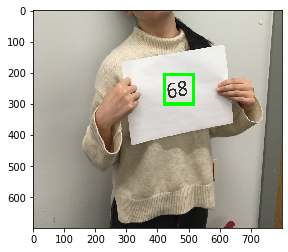

```python
image_hard_drawn = mpimg.imread(filename_hard)
cv2.drawContours(image_hard_drawn,box_lst,1,(0,255,0),10)
plt.imshow(image_hard_drawn)
plt.show()
```

The full image recognition model, including all hyperparameters, is included in the Appendix at the end of this report.

## Implementing Pytesseract

Pytesseract, short for Python-tesseract, is an OCR tool for Python and a wrapper for Google's Tesseract-OCR Engine. It has been trained over the years on millions of images containing text using a CNN. It is powerful and highly accurate, hence the decision to use it for this project.

Now that we have extracted the boxes containing the 2-digit numbers, one would think that we could simply feed it into Pytesseract and it would correctly output the digits. That is not correct - to achieve good performance many additional steps need to be taken, both in terms of imaging processing as well as customizing the OCR module itself.

### Cropping the images

I crop the images using the coordinates of the bounding boxes.

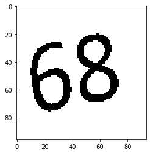

```python
rect = cv2.minAreaRect(box_lst[1])
x,y,w,h = cv2.boundingRect(box_lst[1])
box = img[y:y+h,x:x+w]
box_gray = cv2.cvtColor(box,cv2.COLOR_BGR2GRAY)
_,thresh = cv2.threshold(box_gray, 105,255, cv2.THRESH_BINARY)
plt.imshow(thresh,cmap=plt.get_cmap('gray'))
plt.show()
```

Then I write the cropped number as an image file. By using the same filename, this file will be overwritten at each iteration and this is beneficial since we do not want to store files unnecessarily.

```python
filename = 'cropped.jpeg'
cv2.imwrite(filename, thresh)
```

```
True
```

### Run Pytesseract OCR Module

To render the cropped image as a machine-readable number, run Pytesseract using the following parameters. As you can see, we got the correct result for this particular image.

```python
text = pytesseract.image_to_string(Image.open(filename ),
                                   config='--psm 100 --eom 3 -c tessedit_char_whitelist=0123456789')
print('OCR result: ',text)
```

```
OCR result:  68
```

## Accuracy calculation

The result of the OCR model is package inside the detectNum function in the Appendix. Each filename contains the correct prediction of the image. Hence calculating the accuracy involves looping through all 345 images in the images folder, passing the image through the detectNum function and comparing the results to the prediction. The results are calculated below. Using just this simple analysis, we are able to achieve an accuracy of over 70%.

```python
directory = 'images/'
accuracy_lst = []
count = 0
for fname in os.listdir(directory):
    if fname.lower().endswith('.jpg'):
        count+=1
        true_class = fname.split('_')[1][-2:]
        try:
            pred = detectNum(directory + fname)
        except:
            pred = fname
        if true_class==pred:
            accuracy_lst.append(1)
        else:
            accuracy_lst.append(0)
print('OCR accuracy: ',round(sum(accuracy_lst)/count*100,2),'%')
```

```
OCR accuracy:  70.72 %
```

## Appendix

```python
import cv2
import numpy as np
import os
import PIL
import pytesseract
from PIL import Image

def detectNum(filename):
    if filename.lower().endswith('.jpg'): # it is an image if lower case ends with '.jpg' (also works for '.JPG')
        filename = filename
        img_big=cv2.imread(filename)#img equals location of specific file we want to analyze
        img = cv2.resize(img_big, (800, 700))  # image resize

        imgray = cv2.cvtColor(img,cv2.COLOR_BGR2GRAY) #convert to gray
        _,thresh = cv2.threshold(imgray, 180,255, cv2.THRESH_BINARY_INV) #threshhold
        kernel = cv2.getStructuringElement(cv2.MORPH_RECT,(5,5)) #rectangle shape
        dilated = cv2.dilate(thresh, kernel,iterations=2) # dilate twice the threshold image

        contours,_ = cv2.findContours(dilated.copy(),cv2.RETR_LIST,cv2.CHAIN_APPROX_NONE) #find contours
        box_lst=[] # empty list where to store
        case=0 # allows us to toggle between the different use case of how to treat the image

        for cnt in contours:
            area = cv2.contourArea(cnt)
            rect=cv2.minAreaRect(cnt)
            if (area>=5200) and (area<=200000) and (rect[1][0] < (2.5*rect[1][1])):
                box=cv2.boxPoints(rect)
                box=np.int0(box)

                if (box[1][0]<=5) or (box[2][1]<78) or \
                    (box[3][1]<101) or (box[3][1]>695) or \
                    (box[3][0]>755) or (box[1][1]<91) or (box[0][1]>677):
                    pass
                else:
                    box_lst.append(box)

        if len(box_lst)>1:
            box_lst = sorted(box_lst, key=cv2.contourArea, reverse=True)
            cv2.drawContours(img,box_lst,0,(0,255,0),10)

        elif len(box_lst)==1:
            cv2.drawContours(img,box_lst,-1,(0,255,0),10)
        elif len(box_lst)==0:
            case+=1
            hsv = cv2.cvtColor(img, cv2.COLOR_BGR2HSV)

            hsv[:, :][1] = hsv[:, :][2]*1.1
            hsv[:, :][2] = hsv[:, :][2]*1.1

            bgr = cv2.cvtColor(img, cv2.COLOR_HSV2BGR)
            gray = cv2.cvtColor(hsv, cv2.COLOR_BGR2GRAY)
            edges = cv2.Canny(gray,100,200)
            kernel = cv2.getStructuringElement(cv2.MORPH_RECT,(4,5))
            dilated = cv2.dilate(edges, kernel,iterations=10)
            contours,_ = cv2.findContours(dilated,cv2.RETR_LIST,cv2.CHAIN_APPROX_NONE)

            for cnt in contours:
                area = cv2.contourArea(cnt)
                rect=cv2.minAreaRect(cnt)
                if (area>=5000) and (area<=25000):

                    box=cv2.boxPoints(rect)
                    box=np.int0(box)
                    if (box[0][1]>695) or (box[1][1]<160) or (box[0][0]<20) or (box[2][1]<20) or (box[3][0]>780):
                        pass
                    else:
                        box_lst.append(box)
            if len(box_lst)>1:
                box_lst = sorted(box_lst, key=cv2.contourArea, reverse=True)
                cv2.drawContours(img,box_lst,len(box_lst)-1,(0,255,0),10)
            elif len(box_lst)==1:
                cv2.drawContours(img,box_lst,-1,(0,255,0),10)
            else:
                imgray = cv2.cvtColor(img,cv2.COLOR_BGR2GRAY)
                _,thresh = cv2.threshold(imgray, 200,255, cv2.THRESH_BINARY_INV)

                kernel = cv2.getStructuringElement(cv2.MORPH_RECT,(5,5))
                dilated = cv2.dilate(thresh, kernel,iterations=4)

                contours,_ = cv2.findContours(dilated,cv2.RETR_LIST,cv2.CHAIN_APPROX_NONE)

                for cnt in contours:
                    area = cv2.contourArea(cnt)
                    rect=cv2.minAreaRect(cnt)
                    if (area>=2000) and (area<=20000):
                        box=cv2.boxPoints(rect)
                        box=np.int0(box)
                        box_lst.append(box)
                if len(box_lst)>1:
                    box_lst = sorted(box_lst, key=cv2.contourArea, reverse=True)
                    cv2.drawContours(img,box_lst,len(box_lst)-1,(0,255,0),10)
                elif len(box_lst)==1:
                    cv2.drawContours(img,box_lst,-1,(0,255,0),10)
                else:
                    box=np.array([[205, 583],[192, 406],[579, 377],[592, 554]]) #if no box is found we find a random one
                    box_lst.append(box)

        if case>=0:
            rect = cv2.minAreaRect(box_lst[len(box_lst)-1])
        else:
            rect = cv2.minAreaRect(box_lst[0])

        if case>=0:
            x,y,w,h = cv2.boundingRect(box_lst[len(box_lst)-1])
        else:
            x,y,w,h = cv2.boundingRect(box_lst[0])

        box = img[y:y+h,x:x+w]

        box_gray = cv2.cvtColor(box,cv2.COLOR_BGR2GRAY)

        _,thresh = cv2.threshold(box_gray, 105,255, cv2.THRESH_BINARY)

        kernel = np.ones((2,2), np.uint8)
        erode = cv2.erode(thresh, kernel, iterations=1)

        erode2 = cv2.erode(erode, kernel,iterations=10)

        #find contours
        contours,_ = cv2.findContours(erode2,cv2.RETR_LIST,cv2.CHAIN_APPROX_NONE)

        box_lst2=[]
        for cnt in contours:
            area = cv2.contourArea(cnt)
            rect=cv2.minAreaRect(cnt)

            box2=cv2.boxPoints(rect)
            box2=np.int0(box2)

            box_lst2.append(box2)

        box_lst2 = sorted(box_lst2, key=cv2.contourArea, reverse=True)

        x,y,w,h = cv2.boundingRect(box_lst2[0])

        if len(box_lst2)==1:
            x,y,w,h = cv2.boundingRect(box_lst2[0])
            box = box[y:y+h,x:x+w]
        elif len(box_lst2)>1:
            x,y,w,h = cv2.boundingRect(box_lst2[1])
            box = box[y:y+h,x:x+w]
        else:
            pass

        box_gray = cv2.cvtColor(box,cv2.COLOR_BGR2GRAY)

        _,thresh = cv2.threshold(box_gray, 105,255, cv2.THRESH_BINARY)
        cv2.imwrite(filename + '_box.jpg', thresh)

        text = pytesseract.image_to_string(Image.open(filename + '_box.jpg'),config='--psm 100 --eom 3 -c tessedit_char_whitelist=0123456789')
        if text=='5':
            text = '57'
        elif text=='121':
            text=='08'
        elif text =='2':
            text='70'
        elif text=='8':
            text='60'
        elif len(text)>3:
            text='70'
        elif text=='111':
            text=13
        elif text=='1':
            text='57'
        elif text =='3':
            text='08'
        elif text=='4':
            text='01'
        elif text=='7':
            text='15'

        os.remove(filename + '_box.jpg') #delete the created file

    return(text)
```